# Trabajo Práctico Clustering

Autores/as

Afiliación

Miguel Garrone

Universidad Austral

Lucía Tamplin

Milagros Terán

Martín Ceriotti

Para la descripción del conjunto de datos, no utilizamos SUMMARY debido a que las variables son dicotómicas. Optamos por analizar cada una de las variables con la función TABYL a través de tablas de frecuencias.

```
 nacimientos$eg_menor_30  n   percent
                       0 22 0.4313725
                       1 29 0.5686275
```

## Descripción del conjunto de datos

### Edad gestacional menor a 30 semanas

```
 nacimientos$centro  n    percent
                  A 30 0.58823529
                  B  5 0.09803922
                  C 16 0.31372549
```

### Centro

Para la variable que considera el centro donde se realizó el parto, se observa que el 58,82% de los nacimientos tuvieron lugar en el centro A, el 9,81% tuvo lugar en el centro B y el restante 31,37% en el centro C.

```
 nacimientos$ematerna_mayor_40  n   percent
                             0 42 0.8235294
                             1  9 0.1764706
```

### Edad materna mayor a 40 años

Para la variable que considera la edad de la madre, se observa que el 82,35% de las madres tenían al momento del parto menos de 40 años. El restante 17,65%, eran mayores de 40 años.

```
 nacimientos$hta  n   percent
               0 40 0.7843137
               1 11 0.2156863
```

### Hipertensión arterial

Para la variable que considera la hipertensión arterial de la madre, se observa que el 78,43% de las madres no presentaban hipertensión arterial al momento del parto. El restante 21,57%, sí tenía hipertensión arterial.

```
 nacimientos$sexo_masculino  n   percent
                          0 26 0.5098039
                          1 25 0.4901961
```

### Sexo Masculino

```
 nacimientos$cesarea  n    percent
                   0  2 0.03921569
                   1 49 0.96078431
```

### Cesárea

Para la variable que considera si el parto fue realizado por cesárea o no, se observa que el 96,08% de los partos se realizaron por cesárea, y el restante 3,92% fueron partos naturales.

```
 nacimientos$corti  n   percent
                 0  9 0.1764706
                 1 42 0.8235294
```

### Corticoides

Para la variable que considera si se aplicaron corticoides durante el parto o no, se observa que en un 82,35% de los partos sí se utilizó, y en el restante 17,65% no se aplicaron.

```
 nacimientos$peso_menor_1000  n   percent
                           0 45 0.8823529
                           1  6 0.1176471
```

### Peso menor a 1000g

Para la variable que considera si el recién nacido pesó menos que 1000 gramos, se observa que un 88,24% de los recién nacidos pesaron más de 1000 gramos, y el restante 11,76% pesó menos.

## Agrupamiento jerárquico sobre variables binarias

### Dendograma

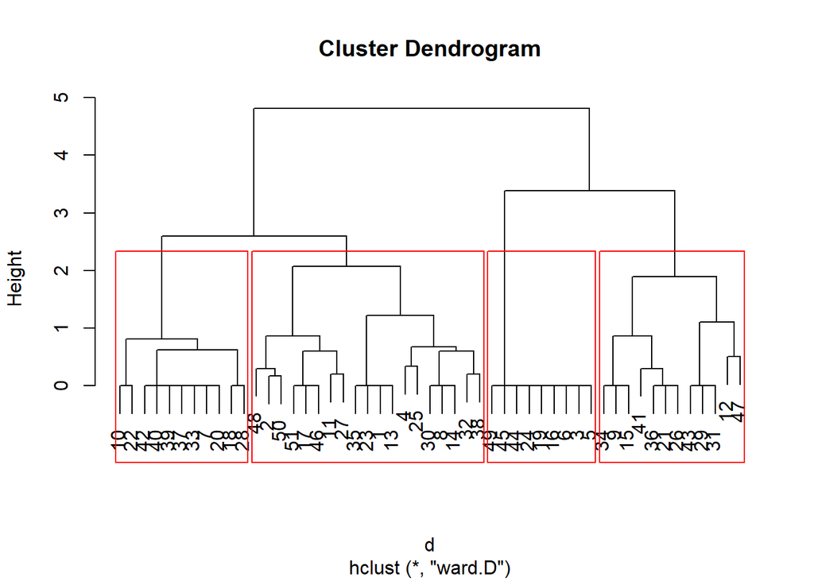

## Cálculo del número óptimo de clusters

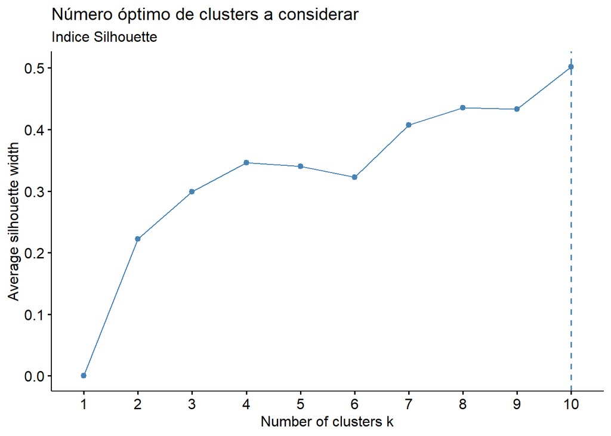

A partir del gráfico del índice de Silhouette se observa que la cantidad óptima de clusters sería 10, pero en este caso, al haber 51 observaciones en total, quedarían muy pocas en cada cluster. Es por esto, y porque se observa un “codo” en el valor 4, que se decidió utilizar esa cantidad de clusters.

## Descripción de las características de los grupos considerados

Se decidió realizar esta discripción a través del uso de tablas de frecuencias dado que las variables son dicotómicas.

```
  cluster eg_menor_30 ematerna_mayor_40  hta sexo_masculino corti cesarea
1       1        94.7              42.1 36.8           21.1  78.9   100.0
2       2         0.0               0.0  0.0            0.0 100.0   100.0
3       3       100.0               0.0  0.0          100.0 100.0    81.8
4       4         0.0               8.3 33.3           83.3  58.3   100.0
  peso_menor_1000
1            15.8
2             0.0
3            18.2
4             8.3
```

A continuación se realiza una breve descripción de la tabla:

Cluster 2: Todos los recién nacidos fueron de género femenino, todas las madres recibieron corticoides en el parto y fueron realizados por cesárea. Además, ninguna de las madres presentaba hipertensión arterial, ni eran mayores a 40 años. Ningún recién nacido tuvo edad gestacional menor a 30 semanas.

Cluster 3: Todos los recién nacidos tuvieron edad gestacional menor a 30 semanas. Además, todos fueron de género masculino. Todas las madres recibieron corticoides y la mayoría tuvo cesarea. La mayoría de los recién nacidos pesaron mas de 1kg. Ninguna madre tenía más de 40 años al momento del parto, ni presentaba hipertensión arterial.

Cluster 4: Ningun recién nacido tuvo edad gestacional menor a 30 semanas. La mayoría de las madres eran menores a 40 años. La mayoría de los recién nacidos eran de sexo masculino. Todos los partos fueron por cesárea, y la mayoría de las mujeres fueron administradas con corticoides. Además, la mayoría de los recién nacidos pesaron mas de 1kg.

## Relación entre la distribución de los nacimientos de los centros (‘A’, ‘B’ y ‘C’) y los distintos clusters

```
    A B C
  1 8 2 9
  2 8 1 0
  3 5 1 5
  4 9 1 2
```

Para el cluster 1, se observa que la mayoría de los nacimientos fueron realizados en los centros A y C. En el cluster 2, se observa que la mayoría de los nacimientos fueron realizados en el centro A. Para el cluster 3, se realizaron nacimientos en igual medida en centros A y C. Por último, en el cluster 4, la mayoría de los nacimientos se realizaron en el centro A. Se observa que el centro B es en el que se realizaron la menor cantidad de nacimientos. Y el cento A, en el que más hubo.

## Agrupamiento jerárquico sobre variables binarias: Utilizando la distancia Sokal Mich

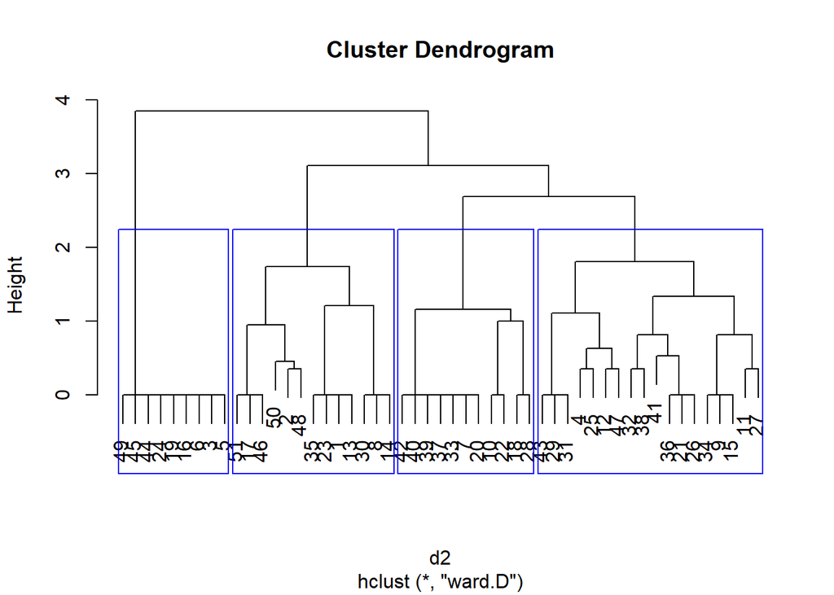

Comparando este dendograma con el obtenido anteriormente, no se observan grandes diferencias. La altura de los cortes es muy similar, aunque se observa que no distribuyeron de la misma manera todas las observaciones, algunas cambiaron de cluster. Evidentemente, considerar las frecuencias de coincidencias 0-0 afecta la distribución de las observaciones en los clusters.

Al observar la base de datos de nacimientos, con los nombres de los clusters, se puede ver que al utilizar los distintos métodos para el cálculo de las distancias, algunas observaciones que se encontraban en el cluster 1 cambiaron al cluster 3. El resto de las observaciones pertenecen a los mismos clusters.

```
  Cluster Frecuencia Proporcion.groups Proporcion.Freq Porcentaje
1       1         19                 1           0.373      37.3%
2       2          9                 2           0.176      17.6%
3       3         11                 3           0.216      21.6%
4       4         12                 4           0.235      23.5%
```

```
  Cluster Frecuencia Proporcion.groups2 Proporcion.Freq Porcentaje
1       1         13                  1           0.255      25.5%
2       2          9                  2           0.176      17.6%
3       3         18                  3           0.353      35.3%
4       4         11                  4           0.216      21.6%
```

A través de estas tablas, se puede ver lo mencionado en el comentario anterior. Los clusters 2 y 4 no sufrieron grandes cambios, a diferencia de los clusters 1 y 3.

```
  cluster2 eg_menor_30 ematerna_mayor_40  hta sexo_masculino corti cesarea
1        1       100.0              46.2 30.8            0.0  92.3   100.0
2        2         0.0               0.0  0.0            0.0 100.0   100.0
3        3        27.8              16.7 38.9           77.8  55.6   100.0
4        4       100.0               0.0  0.0          100.0 100.0    81.8
  peso_menor_1000 cluster
1            23.1     100
2             0.0     200
3             5.6     300
4            18.2     300
```

Cluster 1: Todos los recién nacidos tienen edad gestacional menor a 30 semanas. Un 46.20% de las mujeres eran mayores a 40 años. Todos los recién nacidos fueron de género femenino. Todos los partos fueron realizados por cesárea. Un 23.1% de los recién nacidos pesaron menos de 1kg. Además, la mayoría de las madres recibieron corticoides y un 30.8% de ellas presentaban hipertensión arterial.

Cluster 2: Todos los recién nacidos tienen edad gestacional mayor a 30 semanas. Ninguna de las madres eran mayores de 40 años. Todos los recién nacidos fueron de género femenino. Todos los partos fueron realizados por cesárea. Ninguno de los recién nacidos pesaron menos de 1kg. Además, todas las madres recibieron corticoides y ninguna de ellas presentaba hipertensión arterial.

Cluster 3: Un 27.8% de los recién nacidos tienen edad gestacional menor a 30 semanas. Un 16.7% las madres eran mayores de 40 años. Un 77.8% de los recién nacidos fueron de género masculino. Todos los partos fueron realizados por cesárea. Un 5.6% de los recién nacidos pesaron menos de 1kg. Además, un 55.6% de las madres recibieron corticoides y el 38.9% de ellas presentaba hipertensión arterial.

Cluster 4: Todos los recién nacidos tienen edad gestacional menor a 30 semanas. Ninguna de las madres eran mayores de 40 años. Todos los recién nacidos fueron de género masculino. Un 81.8% de los partos fueron realizados por cesárea. Un 18.2% de los recién nacidos pesaron menos de 1kg. Además, todas las madres recibieron corticoides y ninguna de ellas presentaba hipertensión arterial.

```
     A  B  C
  1  6  1  6
  2  8  1  0
  3 11  2  5
  4  5  1  5
```

En el cluster 1, la mayoría de los nacimientos fueron realizados en los centros A y C. En el cluster 2, la mayoria de los nacimientos fueron realizados en el centro A, y no se realizaron nacimientos en el centro C. Para el cluster 3, la mayoria de los nacimientos fueron realizados en el centro A, seguido del centro C. Por último, en el cluster 4, se realizó la misma cantidad de nacimientos en los centros A y C.  
Se observa que el centro B es en el centro que menos nacimientos se realizaron y el A es el centro en el que se realizaron más.